# Basic statistics

Intro2R crash course: Additional material

Author: [Song, Xiao Ping](https://xp-song.github.io)

Last updated on 2022-10-19

This worksheet provides a brief overview of basic statistics that can be computed using the R programming language.

# 1 Data

## 1.1 Import

First, load the example data `LifeCycleSavings`, which contains the savings ratio (population’s personal savings divided by disposable income) aggregated for selected countries from 1960 to 1970. Five variables (columns) are reported for 50 countries in the world:

- `sr`: aggregate personal savings ratio (in percentage)
- `pop15`: percentage of population under 15
- `pop75`: percentage of population over 75
- `dpi`: real per-capita disposable income
- `ddpi`: percentage growth rate of `dpi`

```r
data(LifeCycleSavings)

# convert rownames to new column
LifeCycleSavings <- cbind(country = rownames(LifeCycleSavings), LifeCycleSavings)
rownames(LifeCycleSavings) <- NULL
```

```r
nrow(LifeCycleSavings) # number of countries
```

```
## [1] 50
```

```r
head(LifeCycleSavings) # see first few rows
```

```
##     country    sr pop15 pop75     dpi ddpi
## 1 Australia 11.43 29.35  2.87 2329.68 2.87
## 2   Austria 12.07 23.32  4.41 1507.99 3.93
## 3   Belgium 13.17 23.80  4.43 2108.47 3.82
## 4   Bolivia  5.75 41.89  1.67  189.13 0.22
## 5    Brazil 12.88 42.19  0.83  728.47 4.56
## 6    Canada  8.79 31.72  2.85 2982.88 2.43
```

View more details by running `?LifeCycleSavings` or `help(LifeCycleSavings)`.

## 1.2 Distribution

Examine the frequency distribution of the personal savings ratio for all 50 countries:

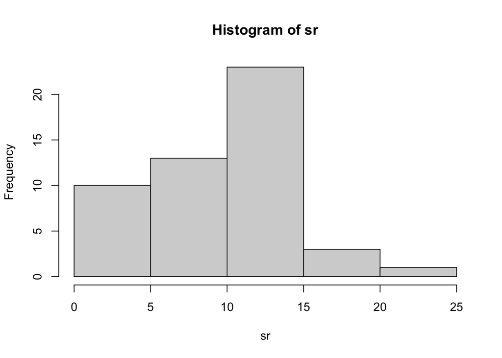

```r
sr <- LifeCycleSavings$sr # assign to variable

hist(sr)
```

Examine the minimum (`min()`) and maximum (`max()`) savings ratio across all countries.

```r
min(sr)
```

```
## [1] 0.6
```

```r
max(sr)
```

```
## [1] 21.1
```

```r
range(sr) # calculate both min & max at once
```

```
## [1]  0.6 21.1
```

Examine the savings ratio at different quantiles across the distribution:

```r
quantile(sr, 0.5) # 50% percentile (0.5 quantile)
```

```
##   50%
## 10.51
```

```r
quantile(sr, c(0.025, 0.25, 0.75, 0.975)) # examine multiple quantiles
```

```
##     2.5%      25%      75%    97.5%
##  1.43875  6.97000 12.61750 18.17525
```

# 2 Summary statistics

## 2.1 Central tendency

Explore summary statistics such as the average (`mean()`) and median (`median()`) savings ratio across all countries.

```r
sum(sr)/length(sr) # manually calculate the mean
```

```
## [1] 9.671
```

```r
mean(sr) # function for arithmetic mean
```

```
## [1] 9.671
```

```r
median(sr) # 50% quantile, not sensitive to outliers
```

```
## [1] 10.51
```

Alternatively, you can view basic summary statistics for all columns using the function `summary()`:

```r
summary(LifeCycleSavings) # calculate for all variables at once
```

```
##    country                sr             pop15           pop75
##  Length:50          Min.   : 0.600   Min.   :21.44   Min.   :0.560
##  Class :character   1st Qu.: 6.970   1st Qu.:26.21   1st Qu.:1.125
##  Mode  :character   Median :10.510   Median :32.58   Median :2.175
##                     Mean   : 9.671   Mean   :35.09   Mean   :2.293
##                     3rd Qu.:12.617   3rd Qu.:44.06   3rd Qu.:3.325
##                     Max.   :21.100   Max.   :47.64   Max.   :4.700
##       dpi               ddpi
##  Min.   :  88.94   Min.   : 0.220
##  1st Qu.: 288.21   1st Qu.: 2.002
##  Median : 695.66   Median : 3.000
##  Mean   :1106.76   Mean   : 3.758
##  3rd Qu.:1795.62   3rd Qu.: 4.478
##  Max.   :4001.89   Max.   :16.710
```

## 2.2 Spread

Calculate the standard deviation (σ), or dispersion around the mean. It is expressed in the same units as the original values:

```r
sqrt(sum((sr - mean(sr))^2) / (length(sr) - 1)) # manually calculate sd, by taking the 'sum of squares' divided by the 'degrees of freedom'
```

```
## [1] 4.480407
```

```r
sd(sr) # function to calculate sd
```

```
## [1] 4.480407
```

Calculate the variance (σ<sup>2</sup>):

```r
sd(sr)^2 # calculate manually from the sd
```

```
## [1] 20.07405
```

```r
var(sr)
```

```
## [1] 20.07405
```

Estimate the standard error:

```r
sd(sr) / sqrt(length(sr)) # manually calculate
```

```
## [1] 0.6336252
```

Note: In sampling, we measure the **standard deviation (SD)** of a sample as a representation of the spread for the entire population (which is unknown). On the other hand, the **standard error (SE)** estimates the spread across *multiple* samples of a population, and gives us an indication of how well the sampled data represents the whole population. A higher sample size will ensure a better representation (accuracy) of the actual spread within the population.

[figure not shown]

**Figure: Difference between SD and SE.** Source: [Scribbr.com](https://www.scribbr.com/statistics/standard-error/)

The SE is often reported as confidence intervals (CIs), which tell us the range of values that an unknown population parameter (e.g., the mean) is expected to be within. It is common practice to report the CI for which 95% of all sample means are expected to be within, i.e., a 95% confidence level:

```r
sample_se <- sd(sr) / sqrt(length(sr)) # formula to calculate SE from SD


# use t-distribution to estimate population SE
# assumes that the data were randomly sampled from whole population, and that the variable follows a normal distribution!

deg_freedom <- length(sr)-1
# 'degrees of freedom' is the max no. of values that are free to vary, in order to arrive at the estimated parameter

t_score <- qt(p = 0.975, df = deg_freedom)
# t-score describes how far away (no. of SD) a data point is from mean of the t-distribution. We want the value for the 97.5% percentile (0.975 quantile), because a two-tailed distribution has 2.5% of data at both ends, which sums up to 5% of data being outside the CI

margin_error <- t_score * sample_se

lower_limit <- mean(sr) - margin_error
upper_limit <- mean(sr) + margin_error
c(lower_limit, upper_limit)
```

```
## [1]  8.397682 10.944318
```

Alternatively, you can use the function `t.test()` to calculate the 95% CI:

```r
t.test(sr, conf.level = 0.95)
```

```
##
##  One Sample t-test
##
## data:  sr
## t = 15.263, df = 49, p-value < 2.2e-16
## alternative hypothesis: true mean is not equal to 0
## 95 percent confidence interval:
##   8.397682 10.944318
## sample estimates:
## mean of x
##     9.671
```

# 3 Study design

## 3.1 Sampling

In experiments or observational studies, random sampling is often required to avoid bias and ensure that the sampled data accurately represents the whole population. This section demonstrates various functions that may be used to for sampling.

First, let’s ‘set the seed’ for R’s random number generator. This will allow us to reproduce the same random sequence whenever the code is re-run in future sessions.

```r
set.seed(1)
```

Simple random sampling may be performed using the function `sample()`. For example, we can randomly sample 5 rows of `LifeCycleSavings` without replacement:

```r
rows <- nrow(LifeCycleSavings)
rows_sampled <- sample(rows, 5, replace = FALSE)
LifeCycleSavings[rows_sampled, ] # subset to sampled rows
```

```
##        country    sr pop15 pop75     dpi ddpi
## 4      Bolivia  5.75 41.89  1.67  189.13 0.22
## 39      Sweden  6.86 21.44  4.54 3299.49 3.01
## 1    Australia 11.43 29.35  2.87 2329.68 2.87
## 34 Philippines 12.78 46.26  1.12  152.01 2.00
## 23       Japan 21.10 27.01  1.91 1257.28 8.21
```

Stratified random sampling can help ensure that the sampled dataset retains the same statistical information of the population. For example, we might want to choose 10 countries for further analysis, while ensuring that the savings ratio among the countries chosen retain the same distribution as the entire population:

```r
# categorise sr into 5 categories based on quantiles (see section 1.2)
sr_quantiles <- quantile(sr, c(0, 0.025, 0.25, 0.75, 0.975, 1))
sr_intervals <- cut(sr, breaks = sr_quantiles, include.lowest = TRUE)
LifeCycleSavings$sr_intervals <- sr_intervals # add intervals as new column
sr_frequencies <- table(sr_intervals) # count frequency of each category
LifeCycleSavings$sr_frequencies <- sr_frequencies[LifeCycleSavings$sr_intervals] # add frequency as new column

# stratified random sampling
rows_sampled <-
  sample(rows, 10, # choose 10 rows
         prob = LifeCycleSavings$sr_frequencies, # higher frequencies have higher probability of being chosen, retain distribution
         replace = FALSE)
LifeCycleSavings[rows_sampled, ] # subset to sampled rows
```

```
##       country    sr pop15 pop75     dpi ddpi sr_intervals sr_frequencies
## 6      Canada  8.79 31.72  2.85 2982.88 2.43  (6.97,12.6]             24
## 18   Honduras  7.70 47.32  0.58  232.44 3.19  (6.97,12.6]             24
## 20      India  9.00 41.31  0.96   88.94 1.54  (6.97,12.6]             24
## 10 Costa Rica 10.78 47.64  1.14  471.24 2.80  (6.97,12.6]             24
## 45  Venezuela  9.22 46.40  0.90  813.39 0.53  (6.97,12.6]             24
## 14     France 12.64 25.06  4.70 2213.82 4.52  (12.6,18.2]             11
## 2     Austria 12.07 23.32  4.41 1507.99 3.93  (6.97,12.6]             24
## 5      Brazil 12.88 42.19  0.83  728.47 4.56  (12.6,18.2]             11
## 21    Ireland 11.34 31.16  4.19 1139.95 2.99  (6.97,12.6]             24
## 50   Malaysia  4.71 47.20  0.66  242.69 5.08  (1.44,6.97]             11
```

On the other hand, we may want *equal* representation among categories/strata, to ensure sufficient variability in the sample. For example, we can ensure a uniform distribution in the savings ratio among the 10 countries chosen:

```r
library(dplyr) # load required package (install if necessary)

slice_sample(
  group_by(LifeCycleSavings, sr_intervals), # group by categories
  n = 2) # 2 countries per category (total of 10)
```

```
## # A tibble: 10 × 8
## # Groups:   sr_intervals [5]
##    country        sr pop15 pop75   dpi  ddpi sr_intervals sr_frequencies
##    <chr>       <dbl> <dbl> <dbl> <dbl> <dbl> <fct>        <table>
##  1 Iceland      1.27  34.0  3.08 1900.  1.12 [0.6,1.44]    2
##  2 Chile        0.6   39.7  1.34  663.  2.67 [0.6,1.44]    2
##  3 Paraguay     2.02  41.2  1.05  221.  1.03 (1.44,6.97]  11
##  4 Turkey       5.13  43.4  1.08  390.  2.96 (1.44,6.97]  11
##  5 Nicaragua    7.3   45.0  1.21  326.  2.48 (6.97,12.6]  24
##  6 Venezuela    9.22  46.4  0.9   813.  0.53 (6.97,12.6]  24
##  7 Italy       14.3   24.5  3.48 1390   3.54 (12.6,18.2]  11
##  8 Philippines 12.8   46.3  1.12  152.  2    (12.6,18.2]  11
##  9 Japan       21.1   27.0  1.91 1257.  8.21 (18.2,21.1]   2
## 10 Zambia      18.6   45.2  0.56  138.  5.14 (18.2,21.1]   2
```

## 3.2 Power analysis

Power analysis is typically used to understand the sample size required to detect an effect. For any of the following tests, given any three of the four factors below, we can determine the fourth:

- **Sample size**: Number of samples collected
- **Effect size**: Magnitude of the effect of interest
- **Significance level**: Probability of finding an effect that is not there (*Type I error*)[^1]
- **Power**: Probability of finding an effect that is there, i.e., rejecting null hypothesis when it is false (*1 - Type II error*)[^2]

```r
library(pwr) # load required package
```

There are many permutations of power calculations, depending on the factor of interest, or the type of test. Some examples to calculate the significance level are shown below:

**T-test of means between two groups:**

```r
pwr.t.test(n = 30, # equal no. of samples between 2 groups
           d = 0.5, # effect size
           sig.level = NULL,
           power = 0.8)
```

```
##
##      Two-sample t test power calculation
##
##               n = 30
##               d = 0.5
##       sig.level = 0.2759254
##           power = 0.8
##     alternative = two.sided
##
## NOTE: n is number in *each* group
```

```r
pwr.t2n.test(n1 = 20, n2 = 30, # if sample sizes are unequal
             d =0.5,
             sig.level = NULL, power = 0.8)
```

```
##
##      t test power calculation
##
##              n1 = 20
##              n2 = 30
##               d = 0.5
##       sig.level = 0.368904
##           power = 0.8
##     alternative = two.sided
```

**ANOVA test for means between multiple groups:**

```r
pwr.anova.test(k = 3, # 3 groups
               n = 30, # no. of samples per grp
               f = 0.5, # effect size
               sig.level = NULL,
               power = 0.8)
```

```
##
##      Balanced one-way analysis of variance power calculation
##
##               k = 3
##               n = 30
##               f = 0.5
##       sig.level = 0.0006734242
##           power = 0.8
##
## NOTE: n is number in each group
```

**Test of proportions between two groups:**

```r
pwr.2p.test(n = 30, # comparing
            h = 0.5, # effect size
            sig.level = NULL, power = 0.8)
```

```
##
##      Difference of proportion power calculation for binomial distribution (arcsine transformation)
##
##               h = 0.5
##               n = 30
##       sig.level = 0.2716841
##           power = 0.8
##     alternative = two.sided
##
## NOTE: same sample sizes
```

Refer to [statsmethods.net](https://www.statmethods.net/stats/power.html) more examples and tests (e.g., Chi-square tests, linear models, correlations).

# 4 Statstical tests

Some of the following sections involve comparisons between multiple groups (factors). Let’s create a new column assigning each country to a continent (group), using the package `countrycode`:

```r
library(countrycode) # load required package

LifeCycleSavings$continent <-
  countrycode(sourcevar = LifeCycleSavings$country,
              origin = "country.name",
              destination = "continent")

head(LifeCycleSavings)
```

```
##     country    sr pop15 pop75     dpi ddpi sr_intervals sr_frequencies
## 1 Australia 11.43 29.35  2.87 2329.68 2.87  (6.97,12.6]             24
## 2   Austria 12.07 23.32  4.41 1507.99 3.93  (6.97,12.6]             24
## 3   Belgium 13.17 23.80  4.43 2108.47 3.82  (12.6,18.2]             11
## 4   Bolivia  5.75 41.89  1.67  189.13 0.22  (1.44,6.97]             11
## 5    Brazil 12.88 42.19  0.83  728.47 4.56  (12.6,18.2]             11
## 6    Canada  8.79 31.72  2.85 2982.88 2.43  (6.97,12.6]             24
##   continent
## 1   Oceania
## 2    Europe
## 3    Europe
## 4  Americas
## 5  Americas
## 6  Americas
```

## 4.1 Correlation

Examine basic relationships between pairs of variables using the function `cor()`. Note that you can specify the type of test within the argument ‘`method`’ (e.g. Pearson, Spearman, or Kendall correlation).

```r
dpi <- LifeCycleSavings$dpi # assign disposable income to new variable
cor(sr, dpi) # correlation coefficient 'r' is weakly positive (range of -1 to 1)
```

```
## [1] 0.2203589
```

```r
cor(sr, dpi)^2 # coefficient of determination 'R squared' - percentage variation in one variable explained by other variable (range of 0-1)
```

```
## [1] 0.04855805
```

```r
cov(sr, dpi) # covariance - measure of joint variability between two numeric variables
```

```
## [1] 978.2825
```

The relationships between all variables (columns) can be examined using the function `plot()`:

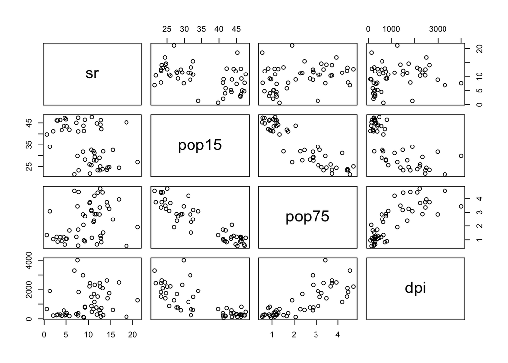

```r
plot(LifeCycleSavings[,2:5]) # only plot for main variables
```